# Lab 2 Solutions

## Exercise 1

```r
new_gapminder <- gapminder %>%
  filter(year == 2007,
         lifeExp >= 70,
         gdpPercap <= 20000)
```

## Exercise 2

```r
gapminder %>%
  filter(year == 2007) %>%
  count(continent)
```

```
## # A tibble: 5 × 2
##   continent     n
##   <fct>     <int>
## 1 Africa       52
## 2 Americas     25
## 3 Asia         33
## 4 Europe       30
## 5 Oceania       2
```

## Exercise 3

```r
new_gapminder <- gapminder %>%
  mutate(log_gdp_percap = log(gdpPercap))
```

## Exercise 4

```r
gapminder %>%
  mutate(log_gdp_percap = log(gdpPercap)) %>%
  filter(year == 2007, lifeExp >= 70) %>%
  summarize(median_log_gdp = median(log_gdp_percap))
```

```
## # A tibble: 1 × 1
##   median_log_gdp
##            <dbl>
## 1           9.40
```

## Exercise 5

```r
gapminder %>%
  mutate(log_gdp_percap = log(gdpPercap)) %>%
  filter(year == 2007, lifeExp >= 70) %>%
  group_by(continent) %>%
  summarize(median_log_gdp = median(log_gdp_percap))
```

```
## # A tibble: 5 × 2
##   continent median_log_gdp
##   <fct>              <dbl>
## 1 Africa              8.87
## 2 Americas            9.11
## 3 Asia                9.39
## 4 Europe             10.2
## 5 Oceania            10.3
```

## Exercise 6

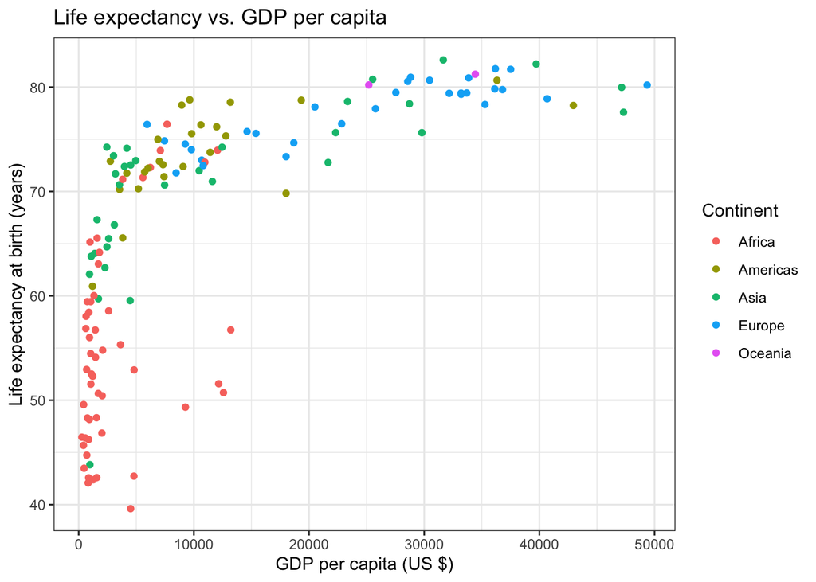

```r
gapminder %>%
  filter(year == 2007) %>%
  ggplot(aes(x = gdpPercap,
             y = lifeExp,
             color = continent)) +
  geom_point() +
  labs(x = "GDP per capita (US $)",
       y = "Life expectancy at birth (years)",
       title = "Life expectancy vs. GDP per capita",
       color = "Continent") +
  theme_bw()
```

## Exercise 7

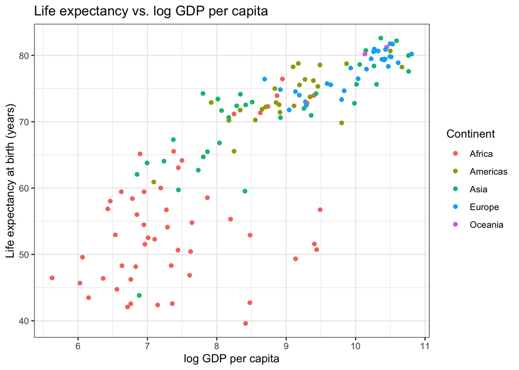

```r
gapminder %>%
  mutate(log_gdp_percap = log(gdpPercap)) %>%
  filter(year == 2007) %>%
  ggplot(aes(x = log_gdp_percap,
             y = lifeExp,
             color = continent)) +
  geom_point() +
  labs(x = "log GDP per capita",
       y = "Life expectancy at birth (years)",
       title = "Life expectancy vs. log GDP per capita",
       color = "Continent") +
  theme_bw()
```

## Exercise 8

```r
gapminder %>%
  mutate(log_gdp_percap = log(gdpPercap)) %>%
  filter(year == 2007) %>%
  group_by(continent) %>%
  summarize(median_life_exp = median(lifeExp),
            r = cor(lifeExp, log_gdp_percap))
```

```
## # A tibble: 5 × 3
##   continent median_life_exp     r
##   <fct>               <dbl> <dbl>
## 1 Africa               52.9 0.452
## 2 Americas             72.9 0.780
## 3 Asia                 72.4 0.800
## 4 Europe               78.6 0.836
## 5 Oceania              80.7 1
```

## Exercise 10

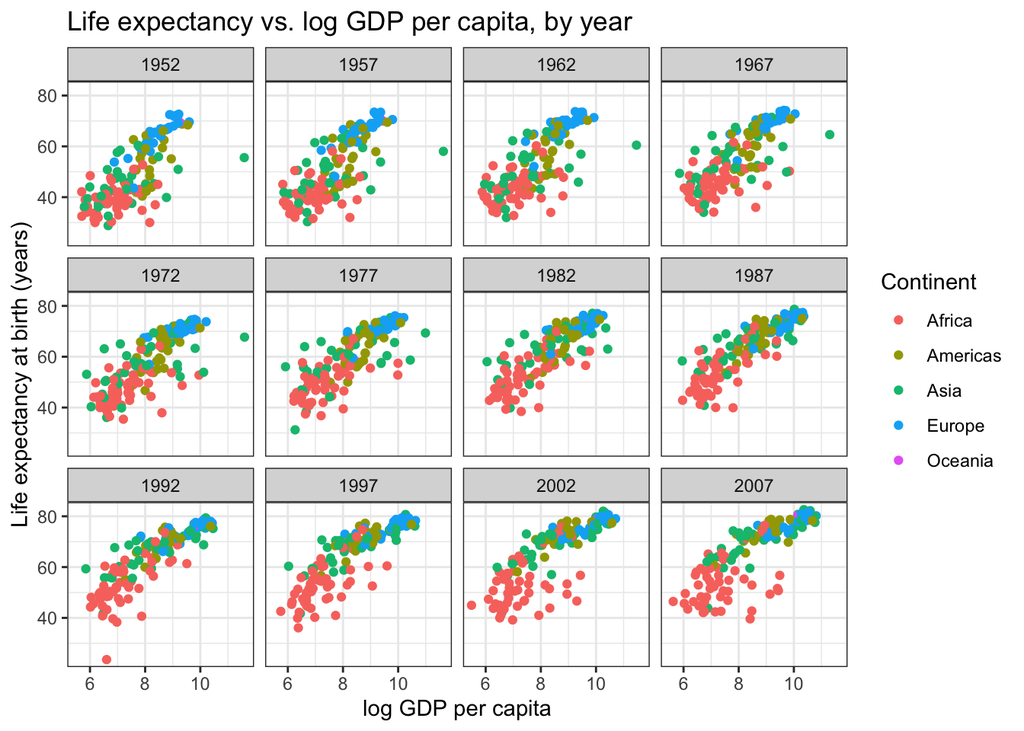

```r
gapminder %>%
  mutate(log_gdp_percap = log(gdpPercap)) %>%
  ggplot(aes(x = log_gdp_percap,
             y = lifeExp,
             color = continent)) +
  geom_point() +
  facet_wrap(~year) +
  labs(x = "log GDP per capita",
       y = "Life expectancy at birth (years)",
       title = "Life expectancy vs. log GDP per capita, by year",
       color = "Continent") +
  theme_bw()
```

## Exercise 11

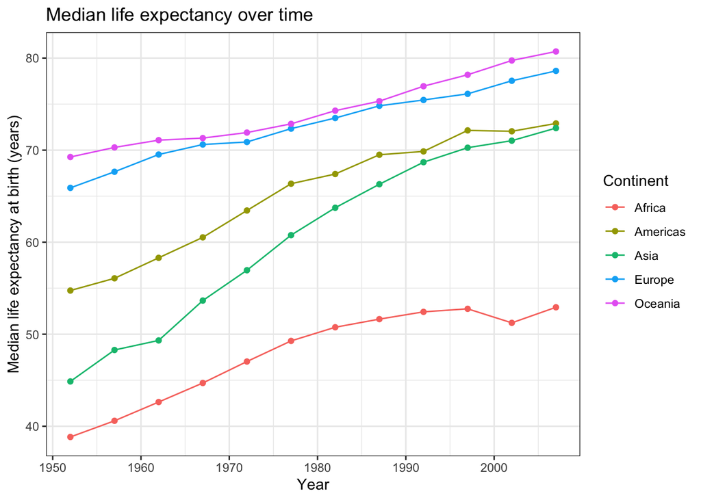

```r
gapminder %>%
  group_by(continent, year) %>%
  summarize(median_life_exp = median(lifeExp)) %>%
  ggplot(aes(x = year,
             y = median_life_exp,
             color = continent)) +
  geom_point() +
  geom_line() +
  labs(x = "Year",
       y = "Median life expectancy at birth (years)",
       color = "Continent",
       title = "Median life expectancy over time") +
  theme_bw()
```

## Exercise 12

From the plot in exercise 10, we can see that countries around the world have made gains in life expectancy, and GDP per capita has increased for many countries. However, it is hard to tell from exercise 10 whether inequality has decreased. It is easier to assess inequality from exercise 11. We can see that the Americas and Asia have almost caught up to Europe and Oceania when it comes to median life expectancy. However, Africa is still just as far away as it was 50 years ago.

While these plots start to address the research question, there are some drawbacks. First, by taking the median life expectancy in each continent, we ignore variability in life expectancy *within* each continent. Second, we’re not measuring inequality directly. If we created a measure of inequality that we could track directly, it might be easier to answer our question.